# Проект ИК

Мардонова Сабина

2024-03-08

```r
library(corrplot)
library(psych)
library(ggplot2)
library(readxl) # для удобства работы с таблицами
library(tidyverse)
library(plm)  # для анализа панельных данных
library(foreign)
```

# 1. Определение цели исследования

### 1.1. Цель исследования.

Проанализировать динамику показателей компании Toyota по регионам (Япония, Северная Америка, Европа, Азия и другие) по ряду ключевых критериев в разрезе времени.

Выручка (Revenue)

Объем продаж (Sales Volume)

Объем производства (Production Volume)

Расходы на НИОКР (R&D Expenses)

Объем экспорта (Export Volume)

### 1.2. Актуальность исследования.

Toyota – один из крупнейших автопроизводителей в мире. Региональные различия в экономических, политических и культурных факторах могут влиять на деятельность компании. Панельные исследования позволяют проанализировать влияние этих факторов в динамике.

# 2. Литературный обзор

### 2.1. “The Performance of Japanese Multinationals: A Panel Data Analysis”

Автор: Masahiro Okuno-Fujiwara and Mitsuyo Ando

Год: 2001

**Методология:**

Панельный анализ данных 156 японских ТНК за 1985-1995 гг. Оценка влияния региональных факторов (таких как ВВП, уровень образования, политическая стабильность) на рентабельность активов (ROA).

**Результаты:**

Региональные факторы значительно влияют на производительность японских ТНК. ВВП и уровень образования положительно коррелируют с ROA. Политическая стабильность негативно коррелирует с ROA.

**Выводы:**

Региональные факторы необходимо учитывать при оценке и планировании деятельности ТНК.

### 2.2. “Regional Differences in Firm Performance: A Panel Data Analysis of Japanese Manufacturing Firms”

Автор: Hiroyuki Imai and Keijiro Otsuka

Год: 2004

**Методология:**

Панельный анализ данных 1264 японских компаний за 1986-1997 гг. Сравнение производительности компаний в разных регионах (Токио, Осака, другие регионы).

**Результаты:**

Производительность компаний выше в Токио и Осаке, чем в других регионах. Различия в производительности связаны с различиями в региональных факторах (таких как наличие квалифицированной рабочей силы, доступ к рынкам).

**Выводы:**

Региональные факторы играют важную роль в различиях производительности компаний.

### 2.3. “The Impact of R&D on Firm Productivity: A Panel Data Analysis of Japanese Firms”

Автор: Yasuyuki Motohashi

Год: 2006

**Методология:**

Панельный анализ данных 748 японских компаний за 1985-1995 гг. Оценка влияния расходов на НИОКР на производительность.

**Результаты:**

Расходы на НИОКР положительно коррелируют с производительностью. Эффект от НИОКР увеличивается с размером компании.

### 2.4. “The Determinants of Firm Export Performance: A Panel Data Analysis of Japanese Firms”

Автор: Takahiro Hattori

Год: 2008

**Методология:**

Панельный анализ данных 1400 японских компаний за 1986-2005 гг. Оценка влияния различных факторов (таких как размер компании, отрасль, регион) на объем экспорта.

**Результаты:**

Размер компании, отрасль и регион влияют на объем экспорта. Экспортная деятельность более развита в крупных компаниях, экспортно-ориентированных отраслях и регионах с развитой инфраструктурой.

**Выводы:**

Для повышения экспортной конкурентоспособности необходимо учитывать влияние различных факторов.

### 2.5. “A Panel Data Analysis of the Determinants of Firm Profitability”

Автор: Junko Koide

Год: 2010

**Методология:**

Панельный анализ данных 1950 японских компаний за 1990-2007 гг. Оценка влияния различных факторов (таких как размер компании, отрасль, возраст компании) на рентабельность.

**Результаты:**

Размер компании, отрасль и возраст компании влияют на рентабельность. Рентабельность выше в крупных компаниях, отраслях с высоким уровнем конкуренции и молодых компаниях.

**Выводы:**

Для повышения рентабельности необходимо учитывать влияние различных факторов.

### 2.6. “The Impact of Regional Factors on Firm Performance: A Panel Data Analysis of Japanese Firms”

Автор: Satoshi Sakamoto

Год: 2012

**Методология:**

Панельный анализ данных 2347 японских компаний за 1990-2007 гг. Оценка влияния региональных факторов (таких как ВВП, уровень образования, плотность населения) на производительность.

**Результаты:**

Региональные факторы влияют на производительность. ВВП и уровень образования положительно коррелируют с производительностью. Плотность населения негативно коррелирует с производительностью.

**Выводы:**

Региональные факторы необходимо учитывать при оценке и планировании деятельности компании.

# 3. Теоретическая часть

### 3.1. Определение панельных данных

Панельные данные (или лонгитюдные данные) – это многомерные данные, получаемые в результате серии измерений или наблюдений за одними и теми же объектами (например, людьми, компаниями, странами) в течение нескольких периодов времени.

Пример:

Ежегодные данные о доходе и потреблении 50 домохозяйств в течение 10 лет.

Ежеквартальные данные о продажах 100 компаний в 4 разных отраслях за 5 лет.

### 3.2. Преимущества панельных данных

**Снижение проблемы гетероскедастичности:** Панельные данные позволяют учитывать индивидуальные особенности объектов, что снижает влияние гетероскедастичности на результаты исследования.

**Контроль за неизменяемыми во времени факторами:** Панельные данные позволяют контролировать влияние неизменяемых во времени факторов (например, пол, раса, генетическая предрасположенность), которые могут искажать результаты исследования.

**Изучение динамических эффектов:** Панельные данные позволяют изучать динамические эффекты, то есть то, как изменения в одной переменной влияют на другую переменную в течение времени.

**Повышение точности оценки параметров:** Панельные данные, как правило, дают более точные оценки параметров, чем поперечные или временные ряды.

### 3.3. Типы панельных данных

**Сбалансированная панель:** Каждый объект наблюдается в каждый период времени.

**Несбалансированная панель:** Некоторые объекты не наблюдаются в некоторые периоды времени.

### 3.4. Модели панельного анализа

**Модель фиксированных эффектов:** Эта модель предполагает, что влияние неизменяемых во времени факторов на каждого объекта одинаково.

**Модель случайных эффектов:** Эта модель предполагает, что влияние неизменяемых во времени факторов на каждого объекта случайно.

**Модель сквозной регрессии:** Эта модель является самой ограничительной из возможных, так как предписывает одинаковое поведение всем объектам выборки во все моменты времени. Если эти предположения выполняются, то параметры модели могут быть состоятельно оценены с помощью метода наименьших квадратов (МНК).

### 3.5. Спецификационные тесты

Чтобы выяснить оценки какой из этих моделей наиболее адекватны нашим данным, необходимо попарное сравнение оцененных моделей.

а) Регрессионную модель с фиксированными эффектами сравним со сквозной регрессией (тест Вальда).

б) Регрессионную модель со случайными эффектами сравним со сквозной регрессией (тест Бройша -Пагана).

в) Регрессионную модель со случайными эффектами сравним с регрессионной моделью с фиксированными эффектами (тест Хаусмана).

### 3.6. Примеры использования панельного анализа

**Изучение влияния образования на заработную плату:** Панельные данные могут быть использованы для изучения того, как образование влияет на заработную плату человека в течение его жизни.

**Изучение влияния государственной политики на экономический рост:** Панельные данные могут быть использованы для изучения того, как государственная политика влияет на экономический рост страны в течение времени.

**Изучение влияния маркетинговых кампаний на продажи:** Панельные данные могут быть использованы для изучения того, как маркетинговые кампании влияют на продажи компании в течение времени.

# 4. База данных

База данных была составлена по информации из следующих источников:

1. Toyota Financial Summary 2023

https://global.toyota/pages/global_toyota/ir/financial-results/2023_4q_summary_en.pdf

2. Toyota Financial Summary 2022

https://global.toyota/pages/global_toyota/ir/financial-results/2022_4q_summary_en.pdf

3. Toyota Financial Summary 2020-2021

https://global.toyota/pages/global_toyota/ir/financial-results/2021_4q_summary_en.pdf

```r
library(readxl)
BDAFinal <- read_excel("C:/Users/Windows 10/Desktop/BDAFinal.xlsx",
    col_types = c("text", "numeric", "numeric",
        "numeric", "numeric", "numeric",
        "numeric"))

BDAFinal$Region <- factor(BDAFinal$Region)

BDAFinal2 <- data.frame (BDAFinal)

BDAFinal <- pdata.frame(BDAFinal, index = c("Region", "Year"), row.names = TRUE)
BDAFinal
```

```
##                           Region Year Revenue SalesVolume ProductionVolume
## Asia-2020                   Asia 2020    5293        1600             1522
## Asia-2021                   Asia 2021    5045        1222             1015
## Asia-2022                   Asia 2022    6530        1543             1499
## Asia-2023                   Asia 2023    8044        1751             1859
## Europe-2020               Europe 2020    3355        1029              674
## Europe-2021               Europe 2021    3134         959              642
## Europe-2022               Europe 2022    3867        1017              707
## Europe-2023               Europe 2023    4273        1030              771
## Japan-2020                 Japan 2020   16441        2240             4413
## Japan-2021                 Japan 2021   14948        2125             3948
## Japan-2022                 Japan 2022   15991        1924             3738
## Japan-2023                 Japan 2023   17583        2069             3789
## North America-2020 North America 2020   10642        2713             1807
## North America-2021 North America 2021    9491        2313             1642
## North America-2022 North America 2022   11166        2394             1752
## North America-2023 North America 2023   13843        2407             1768
## Other-2020                 Other 2020    2114        1372              403
## Other-2021                 Other 2021    1872        1027              306
## Other-2022                 Other 2022    2928        1352              462
## Other-2023                 Other 2023    3472        1566              507
##                    RD_expences ExportVolume
## Asia-2020                  129          387
## Asia-2021                  120          363
## Asia-2022                  138          325
## Asia-2023                  184          355
## Europe-2020                 52          225
## Europe-2021                 61          237
## Europe-2022                 76          215
## Europe-2023                 85          291
## Japan-2020                 376         1794
## Japan-2021                 424         1823
## Japan-2022                 463         1738
## Japan-2023                 512         2010
## North America-2020         212          678
## North America-2021         242          667
## North America-2022         286          574
## North America-2023         366          690
## Other-2020                  32          455
## Other-2021                  28          488
## Other-2022                  43          553
## Other-2023                  35          612
```

# 5. Структура данных

```r
str(BDAFinal)
```

```
## Classes 'pdata.frame' and 'data.frame':  20 obs. of  7 variables:
##  $ Region          : Factor w/ 5 levels "Asia","Europe",..: 1 1 1 1 2 2 2 2 3 3 ...
##   ..- attr(*, "names")= chr [1:20] "Asia-2020" "Asia-2021" "Asia-2022" "Asia-2023" ...
##   ..- attr(*, "index")=Classes 'pindex' and 'data.frame':    20 obs. of  2 variables:
##   .. ..$ Region: Factor w/ 5 levels "Asia","Europe",..: 1 1 1 1 2 2 2 2 3 3 ...
##   .. ..$ Year  : Factor w/ 4 levels "2020","2021",..: 1 2 3 4 1 2 3 4 1 2 ...
##  $ Year            : Factor w/ 4 levels "2020","2021",..: 1 2 3 4 1 2 3 4 1 2 ...
##   ..- attr(*, "names")= chr [1:20] "Asia-2020" "Asia-2021" "Asia-2022" "Asia-2023" ...
##   ..- attr(*, "index")=Classes 'pindex' and 'data.frame':    20 obs. of  2 variables:
##   .. ..$ Region: Factor w/ 5 levels "Asia","Europe",..: 1 1 1 1 2 2 2 2 3 3 ...
##   .. ..$ Year  : Factor w/ 4 levels "2020","2021",..: 1 2 3 4 1 2 3 4 1 2 ...
##  $ Revenue         : 'pseries' Named num  5293 5045 6530 8044 3355 ...
##   ..- attr(*, "names")= chr [1:20] "Asia-2020" "Asia-2021" "Asia-2022" "Asia-2023" ...
##   ..- attr(*, "index")=Classes 'pindex' and 'data.frame':    20 obs. of  2 variables:
##   .. ..$ Region: Factor w/ 5 levels "Asia","Europe",..: 1 1 1 1 2 2 2 2 3 3 ...
##   .. ..$ Year  : Factor w/ 4 levels "2020","2021",..: 1 2 3 4 1 2 3 4 1 2 ...
##  $ SalesVolume     : 'pseries' Named num  1600 1222 1543 1751 1029 ...
##   ..- attr(*, "names")= chr [1:20] "Asia-2020" "Asia-2021" "Asia-2022" "Asia-2023" ...
##   ..- attr(*, "index")=Classes 'pindex' and 'data.frame':    20 obs. of  2 variables:
##   .. ..$ Region: Factor w/ 5 levels "Asia","Europe",..: 1 1 1 1 2 2 2 2 3 3 ...
##   .. ..$ Year  : Factor w/ 4 levels "2020","2021",..: 1 2 3 4 1 2 3 4 1 2 ...
##  $ ProductionVolume: 'pseries' Named num  1522 1015 1499 1859 674 ...
##   ..- attr(*, "names")= chr [1:20] "Asia-2020" "Asia-2021" "Asia-2022" "Asia-2023" ...
##   ..- attr(*, "index")=Classes 'pindex' and 'data.frame':    20 obs. of  2 variables:
##   .. ..$ Region: Factor w/ 5 levels "Asia","Europe",..: 1 1 1 1 2 2 2 2 3 3 ...
##   .. ..$ Year  : Factor w/ 4 levels "2020","2021",..: 1 2 3 4 1 2 3 4 1 2 ...
##  $ RD_expences     : 'pseries' Named num  129 120 138 184 52 61 76 85 376 424 ...
##   ..- attr(*, "names")= chr [1:20] "Asia-2020" "Asia-2021" "Asia-2022" "Asia-2023" ...
##   ..- attr(*, "index")=Classes 'pindex' and 'data.frame':    20 obs. of  2 variables:
##   .. ..$ Region: Factor w/ 5 levels "Asia","Europe",..: 1 1 1 1 2 2 2 2 3 3 ...
##   .. ..$ Year  : Factor w/ 4 levels "2020","2021",..: 1 2 3 4 1 2 3 4 1 2 ...
##  $ ExportVolume    : 'pseries' Named num  387 363 325 355 225 ...
##   ..- attr(*, "names")= chr [1:20] "Asia-2020" "Asia-2021" "Asia-2022" "Asia-2023" ...
##   ..- attr(*, "index")=Classes 'pindex' and 'data.frame':    20 obs. of  2 variables:
##   .. ..$ Region: Factor w/ 5 levels "Asia","Europe",..: 1 1 1 1 2 2 2 2 3 3 ...
##   .. ..$ Year  : Factor w/ 4 levels "2020","2021",..: 1 2 3 4 1 2 3 4 1 2 ...
##  - attr(*, "index")=Classes 'pindex' and 'data.frame':   20 obs. of  2 variables:
##   ..$ Region: Factor w/ 5 levels "Asia","Europe",..: 1 1 1 1 2 2 2 2 3 3 ...
##   ..$ Year  : Factor w/ 4 levels "2020","2021",..: 1 2 3 4 1 2 3 4 1 2 ...
```

У нас представлены панельные данные по 5 переменным.

Количество объектов: 5.

Количество периодов наблюдения: 4

Итого наблюдений: 20

1. Revenue: Выручка
2. SalesVolume: Объем продаж
3. ProductionVolume: Объем производства
4. RD_Expenses: Расходы на НИОКР
5. ExportVolume: Объем экспорта

### 5.1. Тип

1. Revenue: Выручка - количественный непрерывный
2. SalesVolume: Объем продаж - количественный непрерывный
3. ProductionVolume: Объем производства - количественный непрерывный
4. RD_Expenses: Расходы на НИОКР - количественный непрерывный
5. ExportVolume: Объем экспорта - количественный непрерывный
6. Year - количественный дискретный
7. Region - факторный

### 5.2. Шкала измерения

1. Revenue: Выручка - в миллиардах йен
2. SalesVolume: Объем продаж - в тысячах штук машин
3. ProductionVolume: Объем производства - в тысячах штук машин
4. RD_Expenses: Расходы на НИОКР - в миллиардах йен
5. ExportVolume: Объем экспорта - в тысячах штук машин
6. Year - с 2020 по 2023
7. Region - Japan, North america, Europe, Asia, Other

# 6. Описательная статистика. Визуализация

### 6.1. Описательная статистика

```r
summary(BDAFinal)
```

```
##            Region    Year      Revenue       SalesVolume   ProductionVolume
##  Asia         :4   2020:5   Min.   : 1872   Min.   : 959   Min.   : 306
##  Europe       :4   2021:5   1st Qu.: 3443   1st Qu.:1174   1st Qu.: 666
##  Japan        :4   2022:5   Median : 5912   Median :1583   Median :1510
##  North America:4   2023:5   Mean   : 8002   Mean   :1683   Mean   :1661
##  Other        :4            3rd Qu.:11835   3rd Qu.:2154   3rd Qu.:1820
##                             Max.   :17583   Max.   :2713   Max.   :4413
##   RD_expences      ExportVolume
##  Min.   : 28.00   Min.   : 215.0
##  1st Qu.: 58.75   1st Qu.: 347.5
##  Median :133.50   Median : 520.5
##  Mean   :193.20   Mean   : 724.0
##  3rd Qu.:306.00   3rd Qu.: 681.0
##  Max.   :512.00   Max.   :2010.0
```

**Выводы по Revenue.**

Минимальный доход полученный филиалами Тойота по разным регионам в течение 2020-2023 годов равен 1872 миллиард йен в год.

Максимальный доход полученный филиалами Тойота по разным регионам в течение 2020-2023 годов равен 17583 миллиард йен в год.

Средний доход полученный филиалами Тойота по разным регионам в течение 2020-2023 годов равен 8002 миллиард йен в год.

**Выводы по SalesVolume**

Минимальное количество автомобилей, проданных филиалами Тойота по разным регионам в течение 2020-2023 годов равен 959 тысяч штук в год.

Максимальное количество автомобилей, проданных филиалами Тойота по разным регионам в течение 2020-2023 годов равен 2713 тысяч штук в год.

Среднее количество автомобилей, проданных филиалами Тойота по разным регионам в течение 2020-2023 годов равен 1683 тысяч штук в год.

**Выводы по ProductionVolume**

Минимальное количество автомобилей, произведенных филиалами Тойота по разным регионам в течение 2020-2023 годов равен 306 тысяч штук в год.

Максимальное количество автомобилей, произведенных филиалами Тойота по разным регионам в течение 2020-2023 годов равен 4413 тысяч штук в год.

Среднее количество автомобилей, произведенных филиалами Тойота по разным регионам в течение 2020-2023 годов равен 1661 тысяч штук в год.

### 6.2. Визуализация

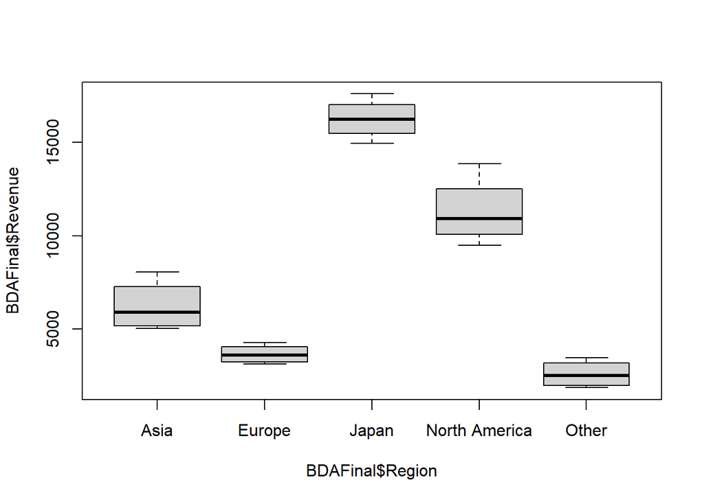

```r
boxplot(BDAFinal$Revenue~ BDAFinal$Region)
```

**Выводы.**

Средний выручка по регионам сильно отличается друг от друга. Самая высокая выручка наблюдается в самой Японии в течение 4 лет. И размер выручки не сильно варьируется и относительно сбалансированна.

Выручка в Северной Америке находится на втором месте после Японии. Средний показатель близок к минимальному, нежели чем к максимальному значению выручки.

Дисперсия выручки в Азии тоже примерно такая же как и в Сев. Америке, но сами показатели значительно ниже.

Что касается Европы и других регионов, у них наблюдается самые низкие показатели выручки за посление 4 года.

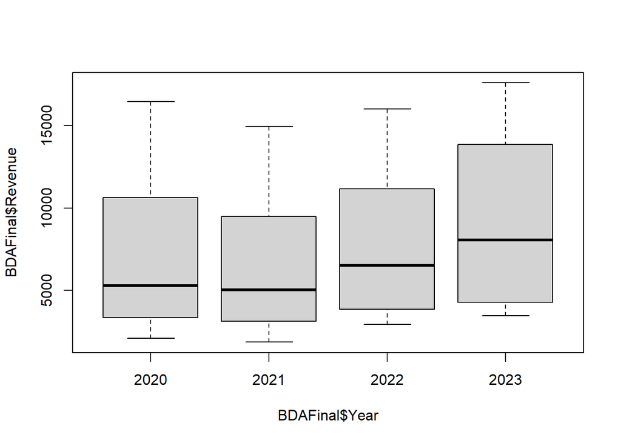

```r
boxplot(BDAFinal$Revenue~ BDAFinal$Year)
```

**Выводы.**

По диаграмме видно, что средняя выручка по всем регионам за последние 4 года имела тенденцию к повышению, но в 2021 году этот показатель ниже, чем в 2020. Это может быть объяснено пандемией COVID-19. Но уде в 2022 году показатель превысил уровень 2020 года.

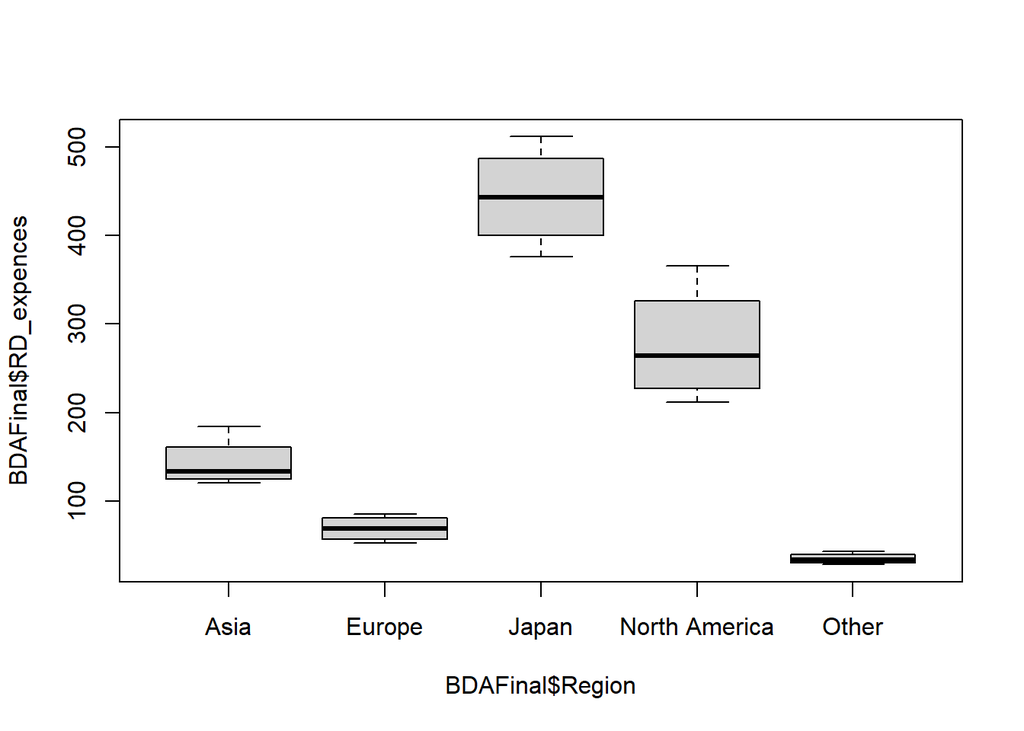

```r
boxplot(BDAFinal$RD_expences~ BDAFinal$Region)
```

**Выводы.**

Расходы на НИОКР по регионам.

Японские филиалы Тойоты тратят больше всех других регионов на НИОКР. После нее лидирует Сев.Америка.

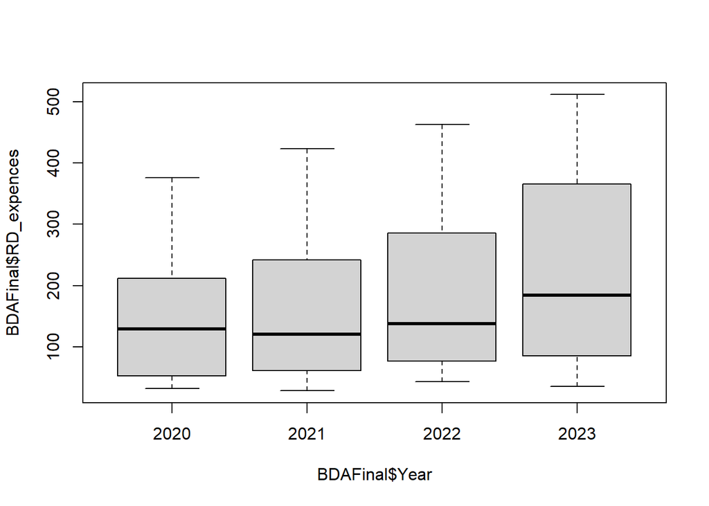

```r
boxplot(BDAFinal$RD_expences~ BDAFinal$Year)
```

**Выводы.**

Расходы на НИОКР по годам.

Так же, как и с выруччкой, расходы на НИОКР снизились в 2021 году, но после этого продолжили расти.

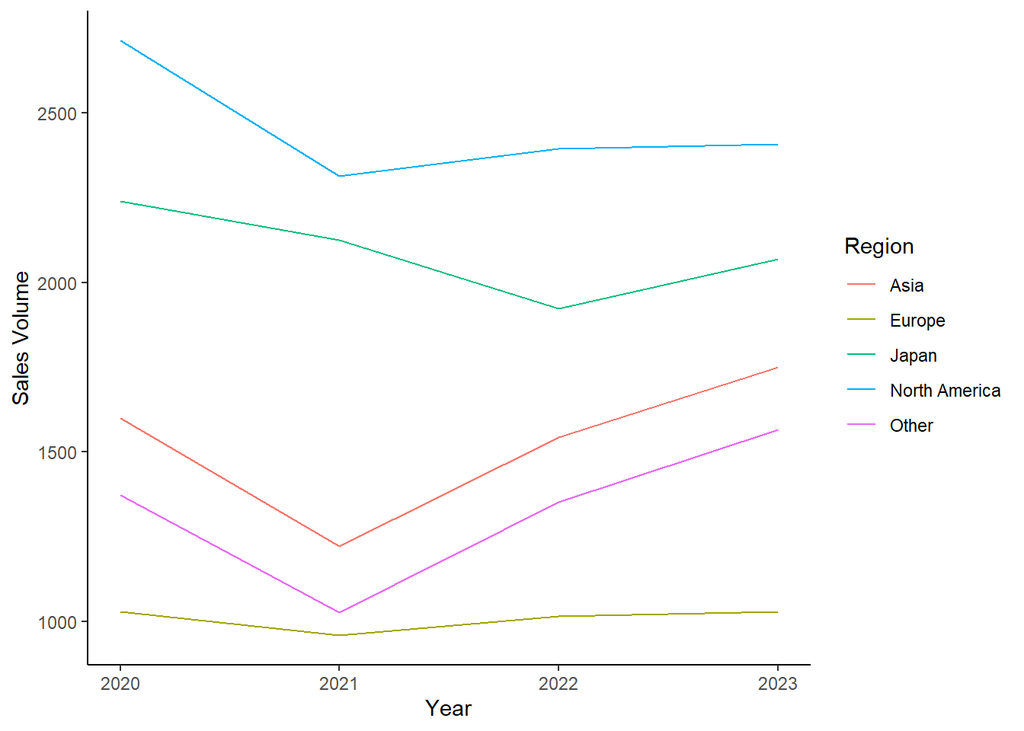

```r
BDAFinal2$Region<-factor(BDAFinal2$Region)
ggplot(data=BDAFinal2,aes(x=Year,y=SalesVolume, color = Region)) +
  geom_line() +
  labs(x="Year",y="Sales Volume",color= "Region")+theme_classic()
```

**Выводы.**

Кривые объема продаж Азии и других регионов очень схожи, что говорит о том что они испытывали одинаковые последствия от пандемии.

# 7. Анализ взаимосвязей между данными

```r
cor_mat <- data.frame(BDAFinal$Revenue,BDAFinal$SalesVolume,BDAFinal$ProductionVolume  , BDAFinal$RD_expences      , BDAFinal$ExportVolume   )
corr_matrix <- cor(cor_mat);corr_matrix
```

```
##                           BDAFinal.Revenue BDAFinal.SalesVolume
## BDAFinal.Revenue                 1.0000000            0.7975909
## BDAFinal.SalesVolume             0.7975909            1.0000000
## BDAFinal.ProductionVolume        0.9386261            0.6461730
## BDAFinal.RD_expences             0.9864470            0.7385376
## BDAFinal.ExportVolume            0.8558946            0.5464842
##                           BDAFinal.ProductionVolume BDAFinal.RD_expences
## BDAFinal.Revenue                          0.9386261            0.9864470
## BDAFinal.SalesVolume                      0.6461730            0.7385376
## BDAFinal.ProductionVolume                 1.0000000            0.9270111
## BDAFinal.RD_expences                      0.9270111            1.0000000
## BDAFinal.ExportVolume                     0.9135655            0.8651431
##                           BDAFinal.ExportVolume
## BDAFinal.Revenue                      0.8558946
## BDAFinal.SalesVolume                  0.5464842
## BDAFinal.ProductionVolume             0.9135655
## BDAFinal.RD_expences                  0.8651431
## BDAFinal.ExportVolume                 1.0000000
```

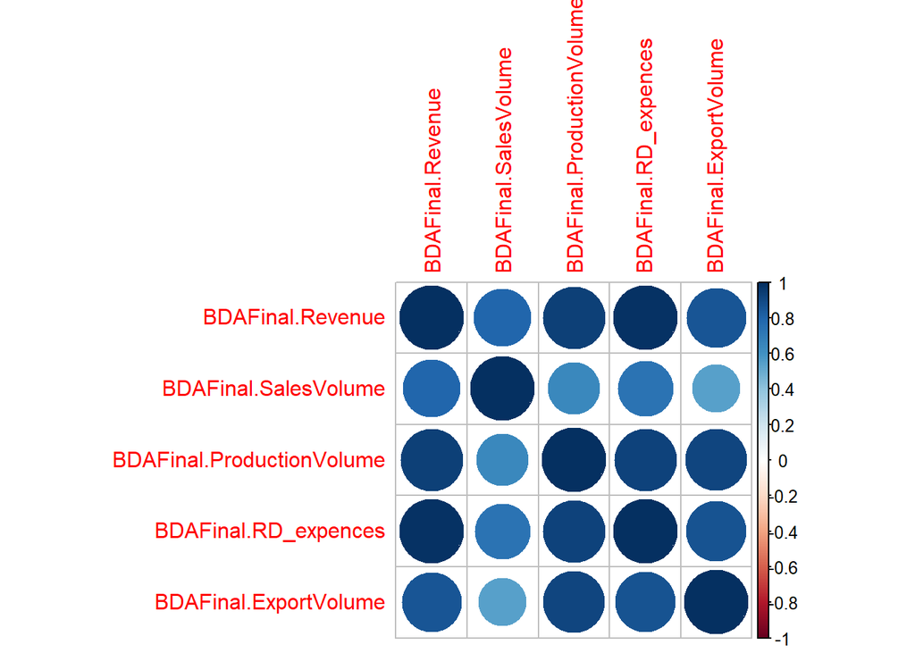

```r
corrplot(corr_matrix)
```

```r
# Выберем только числовые переменные из dataframe
BDAFinal3 <- BDAFinal2[, sapply(BDAFinal2, is.numeric)]

# Удаляем переменную Year из dataframe
numeric_data <- BDAFinal3[, !names(BDAFinal3) %in% c("Year")]

# Коэффициент корреляции Пирсона
cor_pearson <- cor(numeric_data, method = "pearson")

# Коэффициент корреляции Спирмена
cor_spearman <- cor(numeric_data, method = "spearman")

# Коэффициент корреляции Кендалла
cor_kendall <- cor(numeric_data, method = "kendall")

# Вывод результатов
print("Pearson correlation coefficient:")
```

```
## [1] "Pearson correlation coefficient:"
```

```r
print(cor_pearson)
```

```
##                    Revenue SalesVolume ProductionVolume RD_expences
## Revenue          1.0000000   0.7975909        0.9386261   0.9864470
## SalesVolume      0.7975909   1.0000000        0.6461730   0.7385376
## ProductionVolume 0.9386261   0.6461730        1.0000000   0.9270111
## RD_expences      0.9864470   0.7385376        0.9270111   1.0000000
## ExportVolume     0.8558946   0.5464842        0.9135655   0.8651431
##                  ExportVolume
## Revenue             0.8558946
## SalesVolume         0.5464842
## ProductionVolume    0.9135655
## RD_expences         0.8651431
## ExportVolume        1.0000000
```

```r
print("")
```

```
## [1] ""
```

```r
print("Spearman correlation coefficient:")
```

```
## [1] "Spearman correlation coefficient:"
```

```r
print(cor_spearman)
```

```
##                    Revenue SalesVolume ProductionVolume RD_expences
## Revenue          1.0000000   0.7939850        0.9669173   0.9834586
## SalesVolume      0.7939850   1.0000000        0.7473684   0.7518797
## ProductionVolume 0.9669173   0.7473684        1.0000000   0.9578947
## RD_expences      0.9834586   0.7518797        0.9578947   1.0000000
## ExportVolume     0.6977444   0.7759398        0.6225564   0.6631579
##                  ExportVolume
## Revenue             0.6977444
## SalesVolume         0.7759398
## ProductionVolume    0.6225564
## RD_expences         0.6631579
## ExportVolume        1.0000000
```

```r
print("")
```

```
## [1] ""
```

```r
print("Kendall correlation coefficient:")
```

```
## [1] "Kendall correlation coefficient:"
```

```r
print(cor_kendall)
```

```
##                    Revenue SalesVolume ProductionVolume RD_expences
## Revenue          1.0000000   0.5789474        0.8736842   0.9263158
## SalesVolume      0.5789474   1.0000000        0.5789474   0.5052632
## ProductionVolume 0.8736842   0.5789474        1.0000000   0.8421053
## RD_expences      0.9263158   0.5052632        0.8421053   1.0000000
## ExportVolume     0.5473684   0.5473684        0.4842105   0.5157895
##                  ExportVolume
## Revenue             0.5473684
## SalesVolume         0.5473684
## ProductionVolume    0.4842105
## RD_expences         0.5157895
## ExportVolume        1.0000000
```

**Вывод.**

BDAFinal.Revenue и BDAFinal.ProductionVolume (0.938) - Сильная положительная корреляция, означающая, что увеличение объема производства связано с увеличением выручки.

BDAFinal.RD_expences и BDAFinal.Revenue (0.986) и BDAFinal.ProductionVolume (0.927) - Аналогично, существует сильная положительная корреляция между расходами на НИОКР и как выручкой, так и объемом производства, что говорит о том, что инвестиции в исследования и разработки связаны с увеличением выручки и производства.

Существует сильная положительная корреляция между выручкой, объемом производства и расходами на НИОКР. Это означает, что увеличение объема производства и расходов на НИОКР приводит к увеличению выручки.

Существует умеренная положительная корреляция между выручкой и объемом продаж. Это означает, что увеличение объема продаж приводит к увеличению выручки.

Существует сильная положительная корреляция между объемом экспорта и объемом производства, а также расходами на НИОКР. Это означает, что увеличение объема производства и расходов на НИОКР приводит к увеличению объема экспорта.

Но присутсвует мультиколлениарность.

# 8. Построение модели

```r
m.pooled <- plm(Revenue ~ SalesVolume + ProductionVolume + RD_expences + ExportVolume, data = BDAFinal, model = "pooling")
#m.re <- plm(Revenue ~ SalesVolume + ProductionVolume + RD_expences + ExportVolume, data = BDAFinal, model = "random")
m.fe <- plm(Revenue ~ SalesVolume + ProductionVolume + RD_expences + ExportVolume, data = BDAFinal, model = "within")
```

> у нас всего 4 наблюдения для каждого региона, модель случайных эффектов не подходит для анализа этих данных. Вместо этого можем рассмотреть использование модели с фиксированными эффектами (fixed effects), модели пулованных данных (pooled data)

### 8.1. Модель сквозной регрессии

```r
summary(m.pooled)
```

```
## Pooling Model
##
## Call:
## plm(formula = Revenue ~ SalesVolume + ProductionVolume + RD_expences +
##     ExportVolume, data = BDAFinal, model = "pooling")
##
## Balanced Panel: n = 5, T = 4, N = 20
##
## Residuals:
##       Min.    1st Qu.     Median    3rd Qu.       Max.
## -1112.7432  -198.5658     1.1468   360.4781  1022.1738
##
## Coefficients:
##                    Estimate Std. Error t-value  Pr(>|t|)
## (Intercept)      -434.69071  503.37442 -0.8636 0.4014309
## SalesVolume         1.57725    0.37371  4.2205 0.0007415 ***
## ProductionVolume    1.02098    0.34463  2.9625 0.0096843 **
## RD_expences        22.49090    2.66599  8.4362 4.451e-07 ***
## ExportVolume       -0.35768    0.57931 -0.6174 0.5462113
## ---
## Signif. codes:  0 '***' 0.001 '**' 0.01 '*' 0.05 '.' 0.1 ' ' 1
##
## Total Sum of Squares:    541460000
## Residual Sum of Squares: 5211400
## R-Squared:      0.99038
## Adj. R-Squared: 0.98781
## F-statistic: 385.869 on 4 and 15 DF, p-value: 6.3262e-15
```

#### Выводы.

Уравнение регрессии:
$$Revenue_{it}=
-434.69071 + 1.57725 *SalesVolume_{it} + 1.02098 *
ProductionVolume_{it} + 22.49090 * RD_expences_{it} -0.35768
* ExportVolume_{it} + \epsilon_{it}$$

**1. Коэффициенты регрессии:**

SalesVolume: Положительный и значимый коэффициент, 1.57725, говорит о том, что увеличение объема продаж на 1 единицу приводит к увеличению выручки на 1.57725 единиц.

ProductionVolume: Положительный и значимый коэффициент, 1.02098, говорит о том, что увеличение объема производства на 1 единицу приводит к увеличению выручки на 1.02098 единиц.

RD_expences: Положительный и значимый коэффициент, 22.49090, говорит о том, что увеличение расходов на НИОКР на 1 единицу приводит к увеличению выручки на 22.49090 единиц.

ExportVolume: Отрицательный и незначимый коэффициент, -0.35768, говорит о том, что увеличение объема экспорта на 1 единицу приводит к снижению выручки на 0.35768 единиц.

**2. Общие показатели:**

R-квадрат: 0.99038, Значит, изменение выручки может быть обьяснено уравнением регрессии на 99.03% изменением показателей объема производства, продаж, экспорта и расходами на НИОКР

F-статистика: 385.869, p-value: 6.32620e-15, что говорит о том, что модель является статистически значимой.То есть, изменением предикторов можно объяснить хначительную часть изменения выручки.

Результаты т теста: все коэффициенты уравнения регрессии, кроме b_0 и объемов экспорта, значимы

**3. Ограничения:**

Модель не учитывает индивидуальные особенности объектов панели.

Модель не учитывает влияние неизменяемых во времени факторов.

**4. Выводы:**

Результаты панельной регрессии показывают, что объем продаж, объем производства и расходы на НИОКР имеют положительное влияние на выручку.

Объем экспорта имеет отрицательное влияние на выручку, но это влияние не является statistically significant.

Модель является statistically significant и объясняет 99.04% вариации выручки.

### 8.2. Модель c фиксированными эффектами

```r
m.fe <- plm(Revenue ~ SalesVolume + ProductionVolume + RD_expences + ExportVolume, data = BDAFinal, model = "within")

summary(m.fe)
```

```
## Oneway (individual) effect Within Model
##
## Call:
## plm(formula = Revenue ~ SalesVolume + ProductionVolume + RD_expences +
##     ExportVolume, data = BDAFinal, model = "within")
##
## Balanced Panel: n = 5, T = 4, N = 20
##
## Residuals:
##      Min.   1st Qu.    Median   3rd Qu.      Max.
## -850.5396 -177.7241   -9.5472  335.4297  648.9921
##
## Coefficients:
##                  Estimate Std. Error t-value  Pr(>|t|)
## SalesVolume       0.81808    1.52308  0.5371 0.6018776
## ProductionVolume  2.35731    1.16175  2.0291 0.0673552 .
## RD_expences      22.37349    3.83456  5.8347 0.0001134 ***
## ExportVolume      1.74071    2.61408  0.6659 0.5191974
## ---
## Signif. codes:  0 '***' 0.001 '**' 0.01 '*' 0.05 '.' 0.1 ' ' 1
##
## Total Sum of Squares:    21850000
## Residual Sum of Squares: 3530000
## R-Squared:      0.83844
## Adj. R-Squared: 0.72095
## F-statistic: 14.2721 on 4 and 11 DF, p-value: 0.00024822
```

#### Выводы.

Уравнение регрессии:
$$Revenue_{it}=
0.81808 *SalesVolume_{it} + 2.35731 *
ProductionVolume_{it} + 22.37349 * RD_expences_{it} +
1.74071 * ExportVolume_{it} + a_{it} +
\epsilon_{it}$$

**Коэффициенты регрессии:**

SalesVolume: 0.81808 - положительный и незначимый

ProductionVolume: 2.35731 - положительный и незначимый

BD_expences: 22.37349 - положительный и значимый

ExportVolume: 1.74071 - положительный и незначимый

F-статистика: 14.2721, p-value: 0.00024822 - модель статистически значима

R-квадрат: 0.83844 - модель объясняет 83.84% изменения выручки изменениями предикторов.

Adj. R-квадрат: 0.72095 - с учетом числа степеней свободы, модель объясняет 72.09% вариации выручки

**Выводы:**

SalesVolume: Увеличение объема продаж на 1 единицу приводит к увеличению выручки на 0.81808 единиц.

ProductionVolume: Увеличение объема производства на 1 единицу приводит к увеличению выручки на 2.35731 единиц.

BD_expences: Увеличение расходов на НИОКР на 1 единицу приводит к увеличению выручки на 22.37349 единиц.

ExportVolume: Увеличение объема экспорта на 1 единицу приводит к увеличению выручки на 1.74071 единиц.

### 8.3. Тест Вальда

```r
pFtest(m.fe, m.pooled)
```

```
##
##  F test for individual effects
##
## data:  Revenue ~ SalesVolume + ProductionVolume + RD_expences + ExportVolume
## F = 1.3099, df1 = 4, df2 = 11, p-value = 0.3256
## alternative hypothesis: significant effects
```

$$H_0= FE not significant$$
$$H_1= FE significant$$

#### **Выводы.**

Результаты теста вальда. Проверяем значимость фиксированных эффектов. Pvalue > alpha, нулевая гипотеза принимается, фиксированные эффекты незначимы. Предпочтение отдается модели сквозной регрессии pooling нежели модели с фикс эффектами .

Теперь проверим предпосылки модели сквозной регресии.

### 8.4. Проверка выполнения предпосылок модели сквозной регресии.

```r
# Нормальность остатков
shapiro.test(residuals(m.pooled))
```

```
##
##  Shapiro-Wilk normality test
##
## data:  residuals(m.pooled)
## W = 0.97688, p-value = 0.8878
```

#### **Выводы.**

с 95% достоверностью можно утверждать, что остатки модели сквозной регрессии не отклоняются от нормального распределения

```r
# Тест на автокорреляцию остатков
pbgtest(m.pooled)
```

```
##
##  Breusch-Godfrey/Wooldridge test for serial correlation in panel models
##
## data:  Revenue ~ SalesVolume + ProductionVolume + RD_expences + ExportVolume
## chisq = 1.7077, df = 4, p-value = 0.7893
## alternative hypothesis: serial correlation in idiosyncratic errors
```

#### **Выводы.**

Значение статистики хи-квадрат равно 1.7077.

Количество степеней свободы равно 4.

P-значение равно 0.7893.

По результатам теста, на уровне значимости 0.05, нет оснований отвергнуть нулевую гипотезу о отсутствии серийной корреляции в идиосинкратических ошибках модели. Это означает, что нет статистически значимых доказательств наличия автокорреляции в остатках модели сквозной регрессии.

с 95% достоверностью можно утверждать, что нет статистически значимых доказательств автокорреляции в остатках модели сквозной регрессии.

```r
# Тест на гомоскедастичность остатков (Breusch-Pagan test)
library(lmtest)
bptest(m.pooled, studentize = FALSE)
```

```
##
##  Breusch-Pagan test
##
## data:  m.pooled
## BP = 6.2331, df = 4, p-value = 0.1824
```

#### **Выводы.**

Значение статистики BP (Breusch-Pagan) равно 6.2331.

Количество степеней свободы равно 4.

P-значение составляет 0.1824.

При уровне значимости 0.05, нет достаточных статистических доказательств для отвержения нулевой гипотезы о гомоскедастичности остатков. Это означает, что нет статистически значимой гетероскедастичности остатков модели сквозной регрессии.

С 95% достоверностью можно утверждать, что остатки модели сквозной регресии гомоскедактичны.

### 8.5. Кросс-валидация модели сквозной регресии.

```r
library(caret)
# Создаем контроль для кросс-валидации
ctrl <- trainControl(method = "cv", number = 10)

# Обучаем модель и оцениваем ее производительность с использованием кросс-валидации
model <- train(Revenue ~ SalesVolume + ProductionVolume + RD_expences + ExportVolume,
               data = BDAFinal,
               method = "lm",
               trControl = ctrl)

# Выводим результаты кросс-валидации
print(model)
```

```
## Linear Regression
##
## 20 samples
##  4 predictor
##
## No pre-processing
## Resampling: Cross-Validated (10 fold)
## Summary of sample sizes: 18, 18, 18, 18, 18, 18, ...
## Resampling results:
##
##   RMSE      Rsquared  MAE
##   622.1743  1         543.3873
##
## Tuning parameter 'intercept' was held constant at a value of TRUE
```

#### **Выводы.**

R-squared (Коэффициент детерминации): Значение коэффициента детерминации (Rsquared) равно 1. Это означает, что модель объясняет 100% вариации зависимой переменной. Это очень высокий уровень объясненной дисперсии и указывает на отличную соответствие модели данным.

Исходя из этих результатов, можно сделать вывод, что модель линейной регрессии хорошо справляется с предсказанием зависимой переменной на основе предложенных предикторов. Она демонстрирует высокую точность и хорошее соответствие данным.

### 8.6. Проведение анализа остатков модели сквозной регресии.

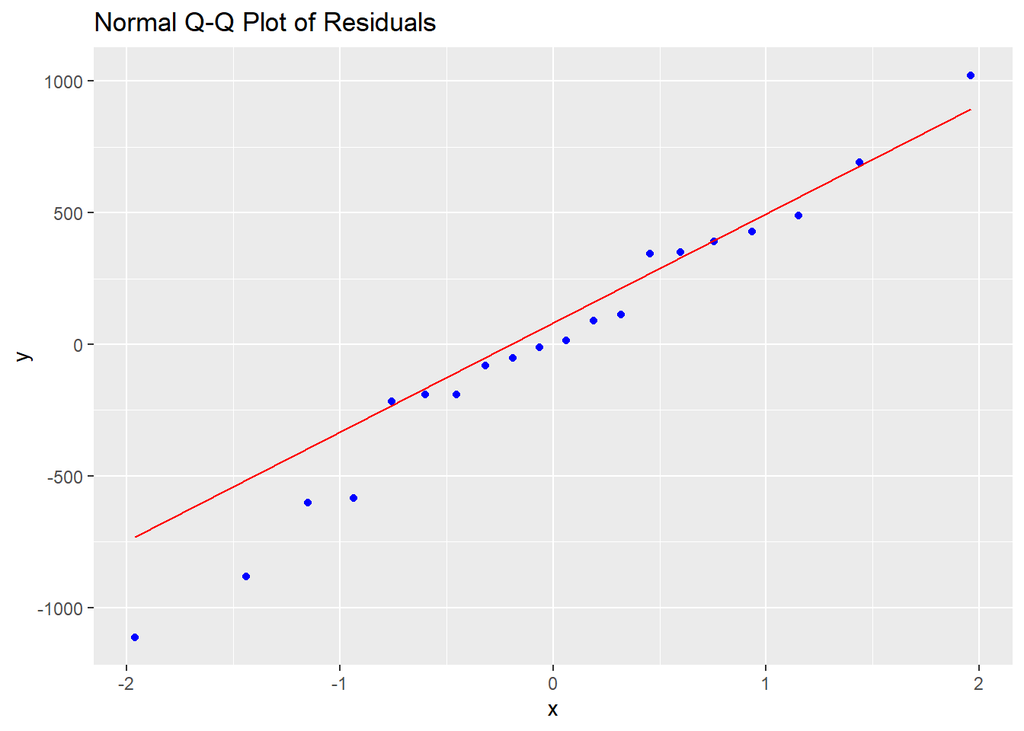

```r
library(ggplot2)

# График нормальной квантильной диаграммы остатков
qq <- ggplot(data.frame(residuals = residuals(m.pooled)), aes(sample = residuals)) +
  geom_qq(color = "blue", fill = "lightblue") +
  geom_qq_line(color = "red") +
  labs(title = "Normal Q-Q Plot of Residuals")
print(qq)
```

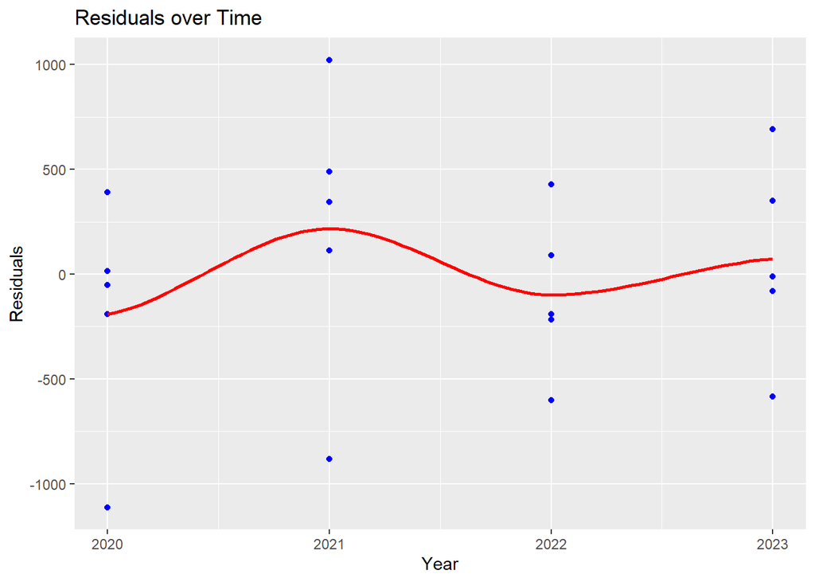

```r
# График остатков по времени
time_resid <- data.frame(Year = BDAFinal2$Year, Residuals = residuals(m.pooled))
time_plot <- ggplot(time_resid, aes(x = Year, y = Residuals)) +
  geom_point(color = "blue") +
  geom_smooth(method = "loess", color = "red", se = FALSE) +
  labs(title = "Residuals over Time", x = "Year", y = "Residuals")
print(time_plot)
```

```r
# Тест на асимметрию и эксцесс остатков
library(e1071)
skew <- skewness(residuals(m.pooled))
kurt <- kurtosis(residuals(m.pooled))
cat("Skewness:", skew, "\n")
```

```
## Skewness: -0.269397
```

```r
cat("Kurtosis:", kurt, "\n")
```

```
## Kurtosis: -0.4350086
```

#### **Выводы.**

Эти результаты указывают на то, что остатки модели не соответствуют полностью нормальному распределению.

### 8.7. Прогнозирование по модели сквозной регресии.

```r
# Прогнозирование по модели на основе обучающих данных
predicted_values <- predict(m.pooled)

# Вывод прогнозов
print(predicted_values)
```

```
##          Asia-2020          Asia-2021          Asia-2022          Asia-2023
##           6405.743           5098.072           6516.952           8236.423
##        Europe-2020        Europe-2021        Europe-2022        Europe-2023
##           2965.488           3020.535           3523.612           3784.693
##         Japan-2020         Japan-2021         Japan-2022         Japan-2023
##          15418.826          15831.878          16207.993          17493.529
## North America-2020 North America-2021 North America-2022 North America-2023
##          10214.861          10094.161          11357.090          13151.711
##         Other-2020         Other-2021         Other-2022         Other-2023
##           2697.715           1952.761           2938.755           3121.200
```

# 9. Экономические выводы

SalesVolume: Положительный и значимый коэффициент, 1.57725, говорит о том, что увеличение объема продаж на 1 единицу приводит к увеличению выручки на 1.57725 единиц.

ProductionVolume: Положительный и значимый коэффициент, 1.02098, говорит о том, что увеличение объема производства на 1 единицу приводит к увеличению выручки на 1.02098 единиц.

RD_expences: Положительный и значимый коэффициент, 22.49090, говорит о том, что увеличение расходов на НИОКР на 1 единицу приводит к увеличению выручки на 22.49090 единиц.

ExportVolume: Отрицательный и незначимый коэффициент, -0.35768, говорит о том, что увеличение объема экспорта на 1 единицу приводит к снижению выручки на 0.35768 единиц.

Анализ остатков и предпосылок модели: Мы провели анализ остатков и проверили предпосылки модели, что позволяет нам с уверенностью интерпретировать результаты модели. Это важно с экономической точки зрения, так как точные и адекватные модели позволяют компаниям принимать более обоснованные решения, основанные на данных.